# Project 2C

## Project 2

Scientific Question: How does gene sequencing on CFTR of different organisms reveal about the effect of the mutation on the CFTR gene to humans?  
Scientific Hypothesis: If humans show a difference in the CFTR gene comparing to mouse, ferrets, and pigs in the gene sequence and structure of the CFTR gene, then this suggests the reason why cystic fibrosis has a significantly larger affect on humans comparing to the other animals.  
CFTR, Cystic Fibrosis Transmembrane Conductance Regulator, is the gene responsible for Cystic Fibrosis, located on chromosome 7. Cystic Fibrosis is a dysfunction of the CFTR channel from exocrine tissues caused by a mutation in the gene. The most common mutation of the CFTR gene is F508del, where a deletion of three nucleotides cause the loss of phenylalanin at the 508th position of the protein.  
For the bioinformatics analysis of this topic, Multiple Sequence Alignment (MSA), Homology Modeling, Sequence logos, and Heatmap is used. The data used for MSA, Homology Modeling, and Sequence Logos are downloaded from Uniprot as individual fasta files. They were then combined into one file after alignment on Uniprot. The data used for the Heatmap is obtained from NCBI (GEO), from "Myosin 7b is a regulatory long noncoding RNA in the human heart" (GSE157217) https://www-ncbi-nlm-nih-gov.ezproxy.u-pec.fr/geo/browse/?view=series&type=3&suppl=CSV&date=01Sep2020&display=20&zsort=title, and downloaded as a csv file. The fasta files were uploaded to SWISS Modeling and pdb files of protein models obtained are used for the coding section of Homology Modeling.

### Part 1: Load the Packages

ProDy: ProDy is a package for protein structural dynamics analysis. It parses PDB and DCD files and the protein structures. It's often used with heterogeneous X-ray structures, Blast searches, NMR models, ANM, and GNM. Heterogeneous X-ray structures are used fro missing residues and mutations, and NMR models are often essential to dynamic analysis. NMWiz can be used with the experimental datasets, simulations, and theoretical to visualize the dynamics. http://prody.csb.pitt.edu  
logomaker: Logomaker is a package that generates sequence logos that illustrates properties of DNA, RNA, and protein sequneces. It makes it convenient to genearte and customize sequence logos within the programming environment. They are rendered as vector graphics embedded ithin native matplotlib Axes objects. It is compatible with both Python 2.7 and 3.6. Many web-programs, such as WebLogo, for making sequence logos are also available. https://academic.oup.com/bioinformatics/article/36/7/2272/5671693 https://logomaker.readthedocs.io/en/latest/  
biotite: Biotite is for identifying homologous sequence regious and finding disulfide bonds in a protein structure. It provides tools to search and fetch data from biological databases and visualizing sequence and structure data. It also allows access to popular sequence/strucutre file formats for the analysis of editing of the data. Most of the data is stored as NumPy ndarray objects to the convenience of C-accelerated analysis and a wider usability. It allows users to skip writing code for basic functionality as a result. https://www.biotite-python.org  
ipython: Ipython is an interactive Python shell that connects the code in Jupyter notebooks to otehr interactive frontends. It allows comprehensive object introspection, extensible tab completion, and session logging and reloading. The package also provide the caching of output results during a session with automatically generated references. The convenience of embeddable in other Python programs makes this package easily usable. Additionally, they also have intergrated access to the pdb debugger and the Python profiler. https://pypi.org/project/ipython/  
pandas: Pandas is the package used for working with data sets, specifically with data analysis, cleaning, exploring, and manipulation. It's one of the most widely used Python package. The name came from the reference to "Panel Data" and "Python Data Analysis". It allows the analysis of large data and users to generate conclusions based on statistical theories. Not only does it clean data sets, it also makes them more readable. https://www.w3schools.com/python/pandas/pandas_intro.asp  
numpy: Another widely used package, Numpy, provides N-dimensional array objects, sophisticated functions that work the C/C++, Fortran, and Python. It is also used as an efficient multi-dimensional container of generic data. The ndarray object provides many supporting functions that make ndarray easy to use. It's faster than lists because they are stored in one place in memory. They are much faster than lists and can be easily manipulated and accessed. https://www.w3schools.com/python/numpy/numpy_intro.asp  
matplotlib: Matplotlib is a package that is used for interactive visualizations in Python. It allows users to create quality plots and customize visual style and layout. It also offers many file formats to export in. Additionally, it offers plotting methods and numerical mathematics extension NumPy. Other packages like SciPy also make use of Matplotlib. https://matplotlib.org https://en.wikipedia.org/wiki/Matplotlib  
seaborn: The seaborn package is a visualization tool based on matplotlib. It provides a quality interface for detailed and informative statistical graphics. Aside from matplotlib, it also uses pandas data strucutres to help users understand and explore data. Seaborn translates values in dataframes to arguments that matplotlib understands. Its functions operate on dataframes and arrays with whole datasets and perform mapping and statistical aggregation to produce plots. https://seaborn.pydata.org/introduction.html

```python
pip install -U ProDy
```

[output not shown]

```python
pip install logomaker
```

```
     |████████████████████████████████| 11.8 MB 1.2 MB/s eta 0:00:01
```

```python
pip install biotite
```

```python
pip install ipython
```

```python
pip install numpy
```

```python
pip install matplotlib
```

```python
pip install pandas
```

```python
pip install seaborn
```

```python
# Import all packages needed
import Bio
from Bio import AlignIO
from Bio.Seq import Seq
from prody import *
from IPython.display import Image
import pandas as pd
import matplotlib.pyplot as plt
import numpy as np
import seaborn as sns
import logomaker
import biotite.sequence as seq
import biotite.sequence.align as align
import biotite.sequence.graphics as graphics
```

### Part 2: Load the Data and Perform Bioinformatics Analyses

Data for the CFTR gene of each species are aligned using Uniprot and downloaded as a compressed fasta file.

```python
# Load cftr.fasta
# Global variable CFTR is the cftr sequence of the four species, human, mouse, ferret, and pig
CFTR = open("cftr.fasta")

# Code check
#for line in CFTR:
    #print(line)
```

[output not shown]

[output cut: 152 more lines]

[output not shown]

```python
# Load cftr_humans_counts.csv
# global variable CFTR_counts is the gene expression of human CFTR gene
CFTR_counts = open("cftr_human1_counts.csv")

# Code check
#for line in CFTR_counts:
    #print(line)
```

[output not shown]

[output cut: 64 more lines]

[output not shown]

### Part 3: Performating Bioinformatics Analysis

#### Multiple Sequence Alignment

Multiple Sequence Alignment is the sequence alignment of three or more protein sequences. It often illustrates mutations as point mutations, and isertion or deletion mutations. It is used to analyze the sequence conservation of protein domains, teritary and secondary structures, and sometimes individual amino acids and nucleotides.

```python
# Read fasta file with alignment
alignment = AlignIO.read("cftr.fasta", "fasta")
print(alignment)
```

```
Alignment with 4 rows and 1484 columns
MQRSPLEKASVVSKLFFSWTRPILRKGYRQRLELSDIYQIPSVD...TRL P13569
MQKSPLEKASFISKLFFSWTTPILRKGYRHHLELSDIYQAPSAD...TRL P26361
MQRSPLEKASIFSKLFFSWTRPILRKGYRQRLELSDIYHISSSD...TRL Q6PQZ2
MQRSPLEKASVLSKLFFSWTRPILTKGYRQRLELSDIYQIPSAD...TRL Q07E16
```

#### Homology Model

Homology modeling is a method that allows the comparison and prediction of two or more protein structures. It is often used for its accuracy and easiness of the method during computational structure prediction. Homology modeling is based on the idea that, "if two proteins share a high enough sequence similarity, they are likely to have very similar three-dimensional structures" https://microbenotes.com/homology-modeling-working-steps-and-uses/

```python
# Homology Model of Human and Pig
# Parse the protein structures of the two models
# Global variable struct1 is the homology model of the CFTR gene of humans
# Local variable struct2 is the homology model of the CFTR gene of pigs
struct1 = parsePDB("human_model.pdb")
struct2 = parsePDB("pig_model.pdb")

# Match chains and store into 2D array called matches
matches = matchChains(struct1,struct2,seqid =90, overlap = 90)

# Code check
#print(matches)

# Calculate the RMSD of chains from both proteins
first_ca = matches[0][0]
second_ca = matches[0][1]
calcRMSD(first_ca, second_ca)

# Apply Kabsch algorithm to ensure that the strucutres are correctly aligned
calcTransformation(first_ca, second_ca).apply(first_ca);

# Run code to get the value fo RMSD
calcRMSD(first_ca, second_ca)
```

[output not shown]

```
[(<AtomMap: Chain A from human_model -> Chain A from pig_model from human_model (1451 atoms)>, <AtomMap: Chain A from pig_model -> Chain A from human_model from pig_model (1451 atoms)>, 100.0, 100.0), (<AtomMap: Chain _ from human_model -> Chain _ from pig_model from human_model (0 atoms)>, <AtomMap…
```

```
2.69610071825823e-14
```

```python
# Homology Model of Human and Ferret
# Parse the protein structures of the two models
# Global variable struct1 is the homology model of the CFTR gene of humans
# Local variable struct2 is the homology model of the CFTR gene of ferrets
struct1 = parsePDB("human_model.pdb")
struct2 = parsePDB("ferret_model.pdb")

# Match chains and store into 2D array called matches
matches = matchChains(struct1,struct2,seqid =50, overlap = 60)

# Code check
#print(matches)

# Calculate the RMSD of chains from both proteins
first_ca = matches[0][0]
second_ca = matches[0][1]
calcRMSD(first_ca, second_ca)

# Apply Kabsch algorithm to ensure that the strucutres are correctly aligned
calcTransformation(first_ca, second_ca).apply(first_ca);

# Run code to get the value fo RMSD
calcRMSD(first_ca, second_ca)
```

[output not shown]

```
[(<AtomMap: Chain A from human_model -> Chain A from ferret_model from human_model (1451 atoms)>, <AtomMap: Chain A from ferret_model -> Chain A from human_model from ferret_model (1451 atoms)>, 52.17091660923501, 99.72508591065292)]
```

```
31.23185148959867
```

```python
# Homology Model of Human and Mouse
# Parse the protein structures of the two models
# Global variable struct1 is the homology model of the CFTR gene of humans
# Local variable struct2 is the homology model of the CFTR gene of mouse
struct1 = parsePDB("human_model.pdb")
struct2 = parsePDB("mouse_model.pdb")

# Match chains and store into 2D array called matches
matches = matchChains(struct1,struct2,seqid =40, overlap = 50)

# Code check
#print(matches)

# Calculate the RMSD of chains from both proteins
first_ca = matches[0][0]
second_ca = matches[0][1]
calcRMSD(first_ca, second_ca)

# Apply Kabsch algorithm to ensure that the strucutres are correctly aligned
calcTransformation(first_ca, second_ca).apply(first_ca);

# Run code to get the value fo RMSD
calcRMSD(first_ca, second_ca)
```

[output not shown]

```
[(<AtomMap: Chain A from human_model -> Chain A from mouse_model from human_model (1447 atoms)>, <AtomMap: Chain A from mouse_model -> Chain A from human_model from mouse_model (1447 atoms)>, 42.22529371112647, 99.72432804962095)]
```

```
19.280079589040554
```

#### Heat Map

```python
# store the file as data
# Local variable, data, reads human's cftr gene expression
data = pd.read_csv("cftr_human1_counts.csv")

# Change the size of the subplot
fig, ax = plt.subplots(figsize=(1,60))

# Chnage the center parameter and map color
sns.heatmap(data.corr(), center = 0, cmap = "Y1GnBu")

# Set heatmap title and plot
ax.set_title("Heat Map")
plt.show()
```

[output not shown]

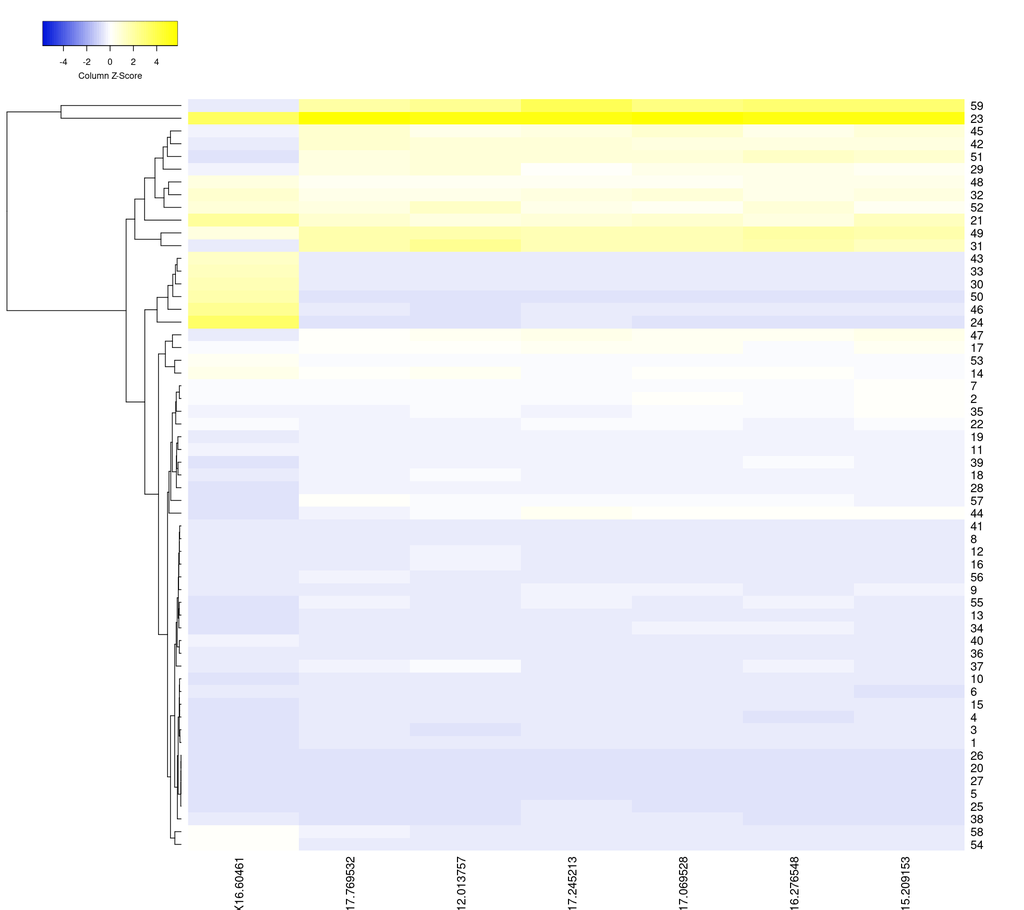

```python
# Include heatmap
Image("heatmap.png")
```

#### Sequence Logos

Sequence Logos is a graphical representation of patterns within a set of aligned sequences. It provides a precise description of a binding site and shows the frequencing of amino or nucleic acids. When there are more characters stacked on top of each other, it means that they are more different. The height of each letter is proportional to its frequency. The most common letter is at the top. The bits in sequence logos is an unit of information. A common web-program used for sequence logos is WebLogo, where it allows users to create their sequence logos on their application.

```python
# Read cftr.fasta, code check
#sequence_df = pd.read_csv("cftr.fasta", comment = ">", names = ["site"])

# Return top rows of the dataframe
#sequence_df.head()
```

[output not shown]

```python
# Read cftr.fasta
# Global variable, alignment, reads the cftr sequences of the four organisms
alignment = AlignIO.read("cftr.fasta", "fasta")

# Create sequence logo from alignment
# File is too big so I included an image below
fig = plt.figure(figsize=(2000, 2000))
ax = fig.add_subplot(111)
profile = seq.SequenceProfile.from_alignment(alignment)
graphics.plot_sequence_logo(ax, profile)

# Remove the entire frame
ax.axis("off")
fig.tight_layout()
plt.show()
```

[output not shown]

[output not shown]

[output cut: 11 more lines]

[output not shown]

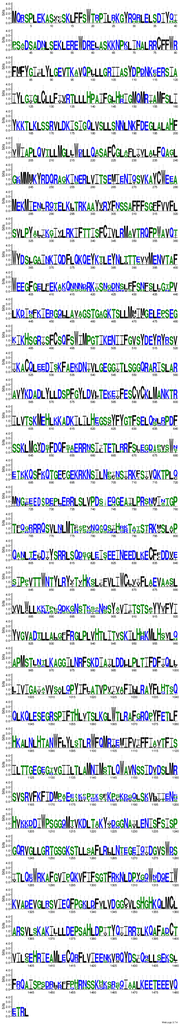

```python
# The sequence logos for this genen is too large (1000+), so I've used Weblogo to include an image
Image("logo.png")
```